# Project

## Step 3 - Preparing the data for analysis

#### Feature Selection using correlation

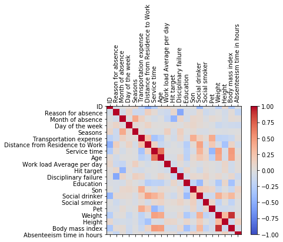

```python
# Now having got an overall idea of the data, lets prepare our data for our analysis
# using the correlation matrix to perform feature i.e. variable selection

corr = AAA.corr()
fig = plt.figure()
ax = fig.add_subplot(111)
cax = ax.matshow(corr,cmap='coolwarm', vmin=-1, vmax=1)
fig.colorbar(cax)
ticks = np.arange(0,len(AAA.columns),1)
ax.set_xticks(ticks)
plt.xticks(rotation=90)
ax.set_yticks(ticks)
ax.set_xticklabels(AAA.columns)
ax.set_yticklabels(AAA.columns)
plt.show()

# We see in the below plot that the follows seems to be highly correlated with each other:
# Age & Service Time
# Weight & Body Mass Index
```

```python
# we can use following code to remove the features that have correlation over 0.6
# Create correlation matrix
corr_matrix = AAA.corr().abs()

# Select upper triangle of correlation matrix
upper = corr_matrix.where(np.triu(np.ones(corr_matrix.shape), k=1).astype(np.bool))

# Find index of feature columns with correlation greater than 0.60
to_drop = [column for column in upper.columns if any(upper[column] > 0.6)]

AAA_new1 = AAA.drop(to_drop, axis=1)
```

```python
# Which volumn is dropped?
to_drop

# As expected, these two columns are dropped from our analysis
```

```
['Age', 'Body mass index']
```

```python
# Also lets drop the ID column, because it does not add anything useful to our analysis
AAA_new1 = AAA_new1.drop(['ID'],axis=1)
```

#### Categorizing the target variable

```python
# Convert the target variable into categories for classification class
AAA_new2 = AAA_new1
def Absenteeism_hours_to_categories(x):
    if x == 0:
        return 0
    if 0 < x <= 8:
        return 1
    if 8 < x <= 40:
        return 2
    if x > 40:
        return 3
AAA_new2['Absenteeism_Class'] = AAA_new2['Absenteeism time in hours'].apply(Absenteeism_hours_to_categories)
AAA_new2['Absenteeism_Class'] = AAA_new2['Absenteeism_Class'].astype(int)
AAA_new1 = AAA_new1.drop(['Absenteeism_Class'],axis=1)
AAA_new = AAA_new2.drop(['Absenteeism time in hours'],axis=1)
```

```python
AAA_new['Absenteeism_Class'].value_counts()
```

```
1    633
2     48
0     44
3     15
Name: Absenteeism_Class, dtype: int64
```

```python
# The features remaining now in our data
AAA_new.head(5)
```

|  | Reason for absence | Month of absence | Day of the week | Seasons | Transportation expense | Distance from Residence to Work | Service time | Work load Average per day | Hit target | Disciplinary failure | Education | Son | Social drinker | Social smoker | Pet | Weight | Height | Absenteeism_Class |
| --- | --- | --- | --- | --- | --- | --- | --- | --- | --- | --- | --- | --- | --- | --- | --- | --- | --- | --- |
| 0 | 26 | 7 | 3 | 1 | 289 | 36 | 13 | 239554 | 97 | 0 | 1 | 2 | 1 | 0 | 1 | 90 | 172 | 1 |
| 1 | 0 | 7 | 3 | 1 | 118 | 13 | 18 | 239554 | 97 | 1 | 1 | 1 | 1 | 0 | 0 | 98 | 178 | 0 |
| 2 | 23 | 7 | 4 | 1 | 179 | 51 | 18 | 239554 | 97 | 0 | 1 | 0 | 1 | 0 | 0 | 89 | 170 | 1 |
| 3 | 7 | 7 | 5 | 1 | 279 | 5 | 14 | 239554 | 97 | 0 | 1 | 2 | 1 | 1 | 0 | 68 | 168 | 1 |
| 4 | 23 | 7 | 5 | 1 | 289 | 36 | 13 | 239554 | 97 | 0 | 1 | 2 | 1 | 0 | 1 | 90 | 172 | 1 |

```python
AAA_new.shape
```

```
(740, 18)
```

## Step 4 - Clustering the data (K-Means)

```python
AAA_C = AAA_new2
```

```
At k=  2 The percentage of change in SSE is  -2010070.1782326014 %
At k=  3 The percentage of change in SSE is  46.25277204423269 %
At k=  4 The percentage of change in SSE is  46.41532387687889 %
At k=  5 The percentage of change in SSE is  30.218265159559245 %
At k=  6 The percentage of change in SSE is  45.13496972023401 %
At k=  7 The percentage of change in SSE is  35.49904789408273 %
At k=  8 The percentage of change in SSE is  31.942096794666817 %
At k=  9 The percentage of change in SSE is  24.097131929162025 %
At k=  10 The percentage of change in SSE is  27.77915840007549 %
At k=  11 The percentage of change in SSE is  31.38484941655854 %
At k=  12 The percentage of change in SSE is  24.518655725712634 %
At k=  13 The percentage of change in SSE is  30.603921914395908 %
At k=  14 The percentage of change in SSE is  24.976141339212194 %
```

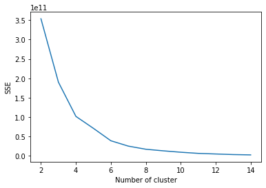

```python
# First, lets try k-means clustering
# Code to generate elbow graph to find the best value for number of cluters, k
from sklearn.cluster import KMeans

sse = {}
last_sse = 17592402.70373319
for k in range(2, 15):
    kmeans = KMeans(n_clusters=k, random_state=1234).fit(AAA_C)
    AAA_C["clusters"] = kmeans.labels_
    #print(data["clusters"])
    sse[k] = kmeans.inertia_
    # Inertia: Sum of distances of samples to their closest cluster center
    change_per = (last_sse-kmeans.inertia_)/last_sse*100
    print ('At k= ',k,'The percentage of change in SSE is ',change_per,'%')
    last_sse = kmeans.inertia_
plt.figure()
plt.plot(list(sse.keys()), list(sse.values()))
plt.xlabel("Number of cluster")
plt.ylabel("SSE")
plt.show()
```

```python
# Design a K means algorithm
# Design a model with best k=4
X = AAA_C.drop(['Absenteeism_Class'],axis=1)
y = AAA_C['Absenteeism_Class']

scaler = StandardScaler()
# scaler = MinMaxScaler()
scaler.fit(X)
X_scaled = scaler.transform(X)
# The MinMaxScaler shifts the data such that all features are exactly between 0 and 1
# The StandardScaler in scikit-learn ensures that for each feature the mean is 0 and variance is 1, bringing all features to the same magnitude
# However, this scaling does not ensure any particular minimum or maximum values for the features.

kmeans = KMeans(n_clusters=4, random_state=1234).fit(X_scaled)
pd.Series(kmeans.labels_).value_counts()
```

```
0    294
1    217
3    189
2     40
dtype: int64
```

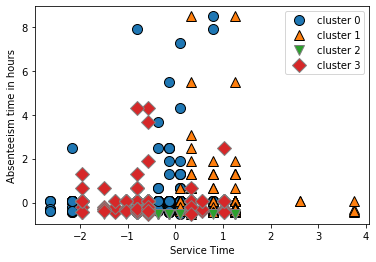

```python
y_pred = kmeans.predict(X_scaled)
mglearn.discrete_scatter(X_scaled[:, 6], X_scaled[:, 17], y_pred)
plt.legend(["cluster 0", "cluster 1", "cluster 2", "cluster 3"], loc='best')
plt.xlabel("Service Time")
plt.ylabel("Absenteeism time in hours")
```

```python
from sklearn.metrics import confusion_matrix
from sklearn.metrics import accuracy_score
# Make a comparison between actual wine type and the predicted one
confusion_matrix(kmeans.labels_, AAA_C['Absenteeism_Class'])
```

```
array([[  1, 268,  18,   7],
       [  1, 191,  20,   5],
       [ 40,   0,   0,   0],
       [  2, 174,  10,   3]])
```

```python
accuracy_score(kmeans.labels_, AAA_C['Absenteeism_Class'])*100
# K-means accuracy is not very good at 26%
```

```
26.351351351351347
```

```python
from sklearn.metrics.cluster import adjusted_rand_score
adjusted_rand_score(kmeans.labels_,AAA_C['Absenteeism_Class'])
# ARI score is extremely low (varies from 0 to 1)
```

```
0.09015790369128797
```

```python
for i in X.columns:
    print('Maximum of ',i, ' is',X[i].max(), ' while mean value is ',X[i].mean())
```

```
Maximum of  Reason for absence  is 28  while mean value is  19.216216216216218
Maximum of  Month of absence  is 12  while mean value is  6.324324324324325
Maximum of  Day of the week  is 6  while mean value is  3.9148648648648647
Maximum of  Seasons  is 4  while mean value is  2.5445945945945945
Maximum of  Transportation expense  is 388  while mean value is  221.32972972972973
Maximum of  Distance from Residence to Work  is 52  while mean value is  29.63108108108108
Maximum of  Service time  is 29  while mean value is  12.554054054054054
Maximum of  Work load Average per day  is 378884  while mean value is  271490.2351351351
Maximum of  Hit target  is 100  while mean value is  94.58783783783784
Maximum of  Disciplinary failure  is 1  while mean value is  0.05405405405405406
Maximum of  Education  is 4  while mean value is  1.2918918918918918
Maximum of  Son  is 4  while mean value is  1.018918918918919
Maximum of  Social drinker  is 1  while mean value is  0.5675675675675675
Maximum of  Social smoker  is 1  while mean value is  0.07297297297297298
Maximum of  Pet  is 8  while mean value is  0.745945945945946
Maximum of  Weight  is 108  while mean value is  79.03513513513514
Maximum of  Height  is 196  while mean value is  172.11486486486487
Maximum of  Absenteeism time in hours  is 120  while mean value is  6.924324324324324
Maximum of  clusters  is 13  while mean value is  6.732432432432432
```

```python
# Centroids
kmeans.cluster_centers_
pd.DataFrame(data=kmeans.cluster_centers_,
             columns=X.columns)

# It is difficult to interpret the clusters due to the scaling on the data
# and because of the low accuracy score, these clusters are not the best split and not identifiable
```

|  | Reason for absence | Month of absence | Day of the week | Seasons | Transportation expense | Distance from Residence to Work | Service time | Work load Average per day | Hit target | Disciplinary failure | Education | Son | Social drinker | Social smoker | Pet | Weight | Height | Absenteeism time in hours | clusters |
| --- | --- | --- | --- | --- | --- | --- | --- | --- | --- | --- | --- | --- | --- | --- | --- | --- | --- | --- | --- |
| 0 | 0.137800 | 0.139313 | 0.095836 | 0.054764 | 0.718180 | 0.249242 | -0.446247 | 0.012321 | -0.053878 | -0.239046 | -0.398468 | 0.692321 | 0.028391 | -0.045170 | 0.660181 | -0.378412 | -0.388458 | 0.086361 | -0.115697 |
| 1 | 0.249387 | -0.142757 | -0.089284 | -0.104424 | -0.591202 | 0.382002 | 1.058784 | 0.026984 | 0.042022 | -0.239046 | -0.433857 | -0.483208 | 0.826362 | -0.245130 | -0.524263 | 0.834850 | 0.379820 | 0.045807 | 0.041160 |
| 2 | -2.280124 | 0.451570 | -0.063253 | 0.634883 | 0.456907 | -0.236470 | -0.000925 | 0.121423 | -0.619006 | 4.183300 | -0.248062 | 0.301601 | 0.216854 | 0.488392 | 0.078986 | 0.302137 | -0.043918 | -0.519767 | -0.045185 |
| 3 | -0.018122 | -0.148374 | -0.033181 | -0.099662 | -0.535081 | -0.776258 | -0.521282 | -0.075846 | 0.166570 | -0.239046 | 1.170471 | -0.585980 | -1.038844 | 0.248347 | -0.441733 | -0.433834 | 0.177472 | -0.076929 | 0.142278 |

#### DBSCAN Clustering

```python
AAA_C = AAA_new2
```

```python
from sklearn.cluster import DBSCAN
X = AAA_C.drop(['Absenteeism_Class'],axis=1)
y = AAA_C['Absenteeism_Class']
dbscan = DBSCAN()
clusters = dbscan.fit_predict(X)
print("Cluster memberships:\n{}".format(clusters))
# As you can see, all data points were assigned the label -1, which stands for noise
# This is a consequence of the default parameter settings for eps and min_samples
```

[output not shown]

```python
scaler = StandardScaler()
scaler.fit(X)
X_scaled = scaler.transform(X)

dbscan = DBSCAN(min_samples=6,eps=4)
clusters = dbscan.fit_predict(X_scaled)
print("Cluster memberships:\n{}".format(clusters))
```

[output not shown]

[output cut: 17 more lines]

```python
pd.Series(clusters).value_counts()
```

```
 0    630
-1     40
 1     36
 2     27
 3      7
dtype: int64
```

```python
AAA_C['Absenteeism_Class'].value_counts()
```

```
1    633
2     48
0     44
3     15
Name: Absenteeism_Class, dtype: int64
```

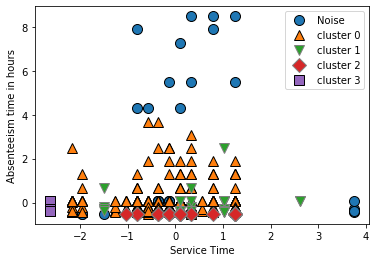

```python
y_pred = dbscan.fit_predict(X_scaled)
mglearn.discrete_scatter(X_scaled[:, 6], X_scaled[:, 17], y_pred)
plt.legend(["Noise", "cluster 0", "cluster 1", "cluster 2", "cluster 3"], loc='best')
plt.xlabel("Service Time")
plt.ylabel("Absenteeism time in hours")
```

```python
confusion_matrix(clusters, AAA_C['Absenteeism_Class'])
```

```
array([[  0,  14,  14,   0,  12],
       [  0,   3, 579,  45,   3],
       [  0,   0,  33,   3,   0],
       [  0,  27,   0,   0,   0],
       [  0,   0,   7,   0,   0]])
```

```python
accuracy_score(clusters, AAA_C['Absenteeism_Class'])*100
```

```
4.864864864864865
```

```python
# ARI
adjusted_rand_score(clusters,AAA_C['Absenteeism_Class'])
```

```
0.40653160486765155
```

#### The DBSCAN Clustering does give better result than k-means clustering (not on accuracy but on ground truth ARI)

### The clustering results for both k-means & DBSCAN are not great. This is because the standard k-means & DBSCAN clustering algorithm isn't directly applicable to categorical data, and lot of features in our data are categorial. The sample space for categorical data is discrete, and doesn't have a natural origin. A Euclidean distance function on such a space isn't really meaningful. The other reason is we categorized our absenteeism class based on only the Absenteeism time in hours, but k-means & DBSCAN is clustering the records on the basis of the other features also, as a result there is a lot of misclassification.